# Act Report

## ACT REPORT

- As we Saw Before In Wrangle Act, We Extract Three Insights From Our DataFrame
- The First One Is The Top Ten Breed Of Dogs Who Have The Most Retweet and Favorite

  1- golden retriever

  2- pembroke

  3- chihuahua

  4- labrador retriever

  5- samoyed

  6- cocker spaniel

  7- french bulldog

  8- chow

  9- malamute

  10- pug
- The Second One Is The Source OF Text ANd There Were Three Sources and Which one of them Most Used

  Twitter for iPhone Was The Most Source Used Then Twitter Web Client, And Then TweetDeck
- And The Third One Was Which Day oF the Week Has The Most Retweet and Favorite Counts

  We Done That By Extract The Day Name from Timestamp Column and Create New Column For it and Grouped By with Retweet and Favorite Counts Then put them in DataFrame To make Visualization on This DataFrame

  The Result Was Monday Was The Most Day OF The Week Has Retweet and Favorite And Saturday Was In The Bottom Of The DataFrame.
- For Visualizing The Combo Chart was The Best Graph For First Insight We Have About Top Ten Breed OF Dog

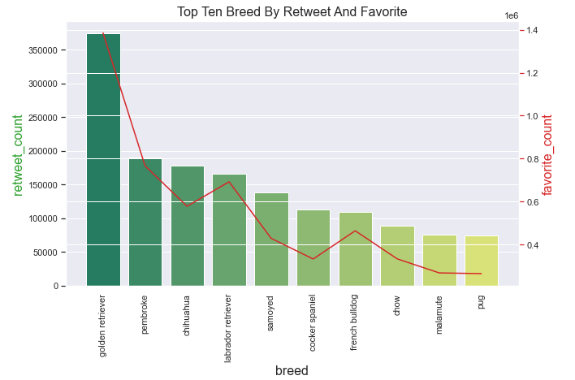